# Install

```python
!git clone https://github.com/junyanz/pytorch-CycleGAN-and-pix2pix
```

```
Cloning into 'pytorch-CycleGAN-and-pix2pix'...
remote: Enumerating objects: 2513, done.
remote: Counting objects: 100% (5/5), done.
remote: Compressing objects: 100% (5/5), done.
remote: Total 2513 (delta 0), reused 4 (delta 0), pack-reused 2508
Receiving objects: 100% (2513/2513), 8.20 MiB | 6.94 MiB/s, done.
Resolving deltas: 100% (1573/1573), done.
```

```python
import os
os.chdir('pytorch-CycleGAN-and-pix2pix/')
```

```python
!pip install -r requirements.txt
```

```
     ━━━━━━━━━━━━━━━━━━━━━━━━━━━━━━━━━━━━━━━━ 1.4/1.4 MB 73.0 MB/s eta 0:00:00
  Preparing metadata (setup.py) ... done
     ━━━━━━━━━━━━━━━━━━━━━━━━━━━━━━━━━━━━━━━━ 2.0/2.0 MB 84.5 MB/s eta 0:00:00
     ━━━━━━━━━━━━━━━━━━━━━━━━━━━━━━━━━━━━━━━━ 55.9/55.9 KB 6.4 MB/s eta 0:00:00
     ━━━━━━━━━━━━━━━━━━━━━━━━━━━━━━━━━━━━━━ 184.3/184.3 KB 20.7 MB/s eta 0:00:00
     ━━━━━━━━━━━━━━━━━━━━━━━━━━━━━━━━━━━━━━ 184.3/184.3 KB 18.6 MB/s eta 0:00:00
  Preparing metadata (setup.py) ... done
     ━━━━━━━━━━━━━━━━━━━━━━━━━━━━━━━━━━━━━━━━ 62.7/62.7 KB 7.3 MB/s eta 0:00:00
```

# Datasets

Download one of the official datasets with:

- `bash ./datasets/download_pix2pix_dataset.sh [cityscapes, night2day, edges2handbags, edges2shoes, facades, maps]`

Or use your own dataset by creating the appropriate folders and adding in the images. Follow the instructions [here](https://github.com/junyanz/pytorch-CycleGAN-and-pix2pix/blob/master/docs/datasets.md#pix2pix-datasets).

```python
!bash ./datasets/download_pix2pix_dataset.sh facades
```

[output not shown]

[output cut: 570 more lines]

[output not shown]

# Pretrained models

Download one of the official pretrained models with:

- `bash ./scripts/download_pix2pix_model.sh [edges2shoes, sat2map, map2sat, facades_label2photo, and day2night]`

```python
!bash ./scripts/download_pix2pix_model.sh facades_label2photo
```

```
Note: available models are edges2shoes, sat2map, map2sat, facades_label2photo, and day2night
Specified [facades_label2photo]
WARNING: timestamping does nothing in combination with -O. See the manual
for details.

--2023-03-16 11:30:14--  http://efrosgans.eecs.berkeley.edu/pix2pix/models-pytorch/facades_label2photo.pth
Resolving efrosgans.eecs.berkeley.edu (efrosgans.eecs.berkeley.edu)... 128.32.244.190
Connecting to efrosgans.eecs.berkeley.edu (efrosgans.eecs.berkeley.edu)|128.32.244.190|:80... connected.
HTTP request sent, awaiting response... 200 OK
Length: 217704720 (208M)
Saving to: ‘./checkpoints/facades_label2photo_pretrained/latest_net_G.pth’

./checkpoints/facad 100%[===================>] 207.62M  16.5MB/s    in 24s

2023-03-16 11:30:38 (8.83 MB/s) - ‘./checkpoints/facades_label2photo_pretrained/latest_net_G.pth’ saved [217704720/217704720]
```

# Training

- `python train.py --dataroot ./datasets/facades --name facades_pix2pix --model pix2pix --direction BtoA`

Change the `--dataroot` and `--name` to your own dataset's path and model's name. Use `--gpu_ids 0,1,..` to train on multiple GPUs and `--batch_size` to change the batch size. Add `--direction BtoA` if you want to train a model to transfrom from class B to A.

```python
!python train.py --dataroot ./datasets/facades --name facades_pix2pix --model pix2pix --direction BtoA --display_id -1
```

```
----------------- Options ---------------
               batch_size: 1
                    beta1: 0.5
          checkpoints_dir: ./checkpoints
           continue_train: False
                crop_size: 256
                 dataroot: ./datasets/facades            	[default: None]
             dataset_mode: aligned
                direction: BtoA                          	[default: AtoB]
              display_env: main
             display_freq: 400
               display_id: -1                            	[default: 1]
            display_ncols: 4
             display_port: 8097
           display_server: http://localhost
          display_winsize: 256
                    epoch: latest
              epoch_count: 1
                 gan_mode: vanilla
                  gpu_ids: 0
                init_gain: 0.02
                init_type: normal
                 input_nc: 3
                  isTrain: True                          	[default: None]
                lambda_L1: 100.0
                load_iter: 0                             	[default: 0]
                load_size: 286
                       lr: 0.0002
           lr_decay_iters: 50
                lr_policy: linear
         max_dataset_size: inf
                    model: pix2pix                       	[default: cycle_gan]
                 n_epochs: 100
           n_epochs_decay: 100
               n_layers_D: 3
                     name: facades_pix2pix               	[default: experiment_name]
                      ndf: 64
                     netD: basic
                     netG: unet_256
                      ngf: 64
```

[output cut: 1271 more lines]

```
End of epoch 198 / 200 	 Time Taken: 27 sec
learning rate 0.0000040 -> 0.0000020
(epoch: 199, iters: 100, time: 0.104, data: 0.235) G_GAN: 5.083 G_L1: 19.285 D_real: 0.016 D_fake: 0.012
(epoch: 199, iters: 200, time: 0.093, data: 0.002) G_GAN: 3.476 G_L1: 22.043 D_real: 0.024 D_fake: 0.056
(epoch: 199, iters: 300, time: 0.110, data: 0.002) G_GAN: 3.582 G_L1: 13.773 D_real: 0.406 D_fake: 0.042
(epoch: 199, iters: 400, time: 0.578, data: 0.002) G_GAN: 3.190 G_L1: 15.844 D_real: 0.054 D_fake: 0.071
End of epoch 199 / 200 	 Time Taken: 27 sec
learning rate 0.0000020 -> 0.0000000
(epoch: 200, iters: 100, time: 0.110, data: 0.186) G_GAN: 5.023 G_L1: 13.696 D_real: 0.034 D_fake: 0.012
(epoch: 200, iters: 200, time: 0.110, data: 0.002) G_GAN: 1.646 G_L1: 25.142 D_real: 0.051 D_fake: 0.346
(epoch: 200, iters: 300, time: 0.111, data: 0.002) G_GAN: 5.927 G_L1: 19.378 D_real: 0.010 D_fake: 0.006
(epoch: 200, iters: 400, time: 0.700, data: 0.002) G_GAN: 4.660 G_L1: 15.355 D_real: 0.025 D_fake: 0.018
saving the latest model (epoch 200, total_iters 80000)
saving the model at the end of epoch 200, iters 80000
End of epoch 200 / 200 	 Time Taken: 29 sec
```

# Testing

- `python test.py --dataroot ./datasets/facades --direction BtoA --model pix2pix --name facades_pix2pix`

Change the `--dataroot`, `--name`, and `--direction` to be consistent with your trained model's configuration and how you want to transform images.

> from https://github.com/junyanz/pytorch-CycleGAN-and-pix2pix: Note that we specified --direction BtoA as Facades dataset's A to B direction is photos to labels.

> If you would like to apply a pre-trained model to a collection of input images (rather than image pairs), please use --model test option. See ./scripts/test_single.sh for how to apply a model to Facade label maps (stored in the directory facades/testB).

> See a list of currently available models at ./scripts/download_pix2pix_model.sh

```python
!ls checkpoints/
```

```
facades_label2photo_pretrained	facades_pix2pix
```

```python
!python test.py --dataroot ./datasets/facades --name facades_pix2pix --model pix2pix --direction BtoA --model pix2pix --name facades_label2photo_pretrained
```

```
----------------- Options ---------------
             aspect_ratio: 1.0
               batch_size: 1
          checkpoints_dir: ./checkpoints
                crop_size: 256
                 dataroot: ./datasets/facades            	[default: None]
             dataset_mode: aligned
                direction: BtoA                          	[default: AtoB]
          display_winsize: 256
                    epoch: latest
                     eval: False
                  gpu_ids: 0
                init_gain: 0.02
                init_type: normal
                 input_nc: 3
                  isTrain: False                         	[default: None]
                load_iter: 0                             	[default: 0]
                load_size: 256
         max_dataset_size: inf
                    model: pix2pix                       	[default: test]
               n_layers_D: 3
                     name: facades_label2photo_pretrained	[default: experiment_name]
                      ndf: 64
                     netD: basic
                     netG: unet_256
                      ngf: 64
               no_dropout: False
                  no_flip: False
                     norm: batch
                 num_test: 50
              num_threads: 4
                output_nc: 3
                    phase: test
               preprocess: resize_and_crop
              results_dir: ./results/
           serial_batches: False
                   suffix:
                use_wandb: False
                  verbose: False
       wandb_project_name: CycleGAN-and-pix2pix
----------------- End -------------------
dataset [AlignedDataset] was created
initialize network with normal
model [Pix2PixModel] was created
loading the model from ./checkpoints/facades_label2photo_pretrained/latest_net_G.pth
---------- Networks initialized -------------
[Network G] Total number of parameters : 54.414 M
-----------------------------------------------
creating web directory ./results/facades_label2photo_pretrained/test_latest
processing (0000)-th image... ['./datasets/facades/test/1.jpg']
processing (0005)-th image... ['./datasets/facades/test/103.jpg']
processing (0010)-th image... ['./datasets/facades/test/12.jpg']
processing (0015)-th image... ['./datasets/facades/test/17.jpg']
processing (0020)-th image... ['./datasets/facades/test/21.jpg']
processing (0025)-th image... ['./datasets/facades/test/26.jpg']
processing (0030)-th image... ['./datasets/facades/test/30.jpg']
processing (0035)-th image... ['./datasets/facades/test/35.jpg']
processing (0040)-th image... ['./datasets/facades/test/4.jpg']
processing (0045)-th image... ['./datasets/facades/test/44.jpg']
```

```python
!python test.py --dataroot ./datasets/facades --direction BtoA --model pix2pix --name facades_label2photo_pretrained --use_wandb
```

[output not shown]

# Visualize

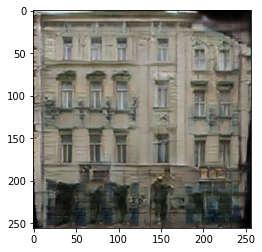

```python
import matplotlib.pyplot as plt

img = plt.imread('./results/facades_label2photo_pretrained/test_latest/images/100_fake_B.png')
plt.imshow(img)
```

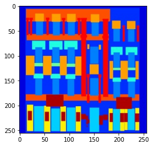

```python
img = plt.imread('./results/facades_label2photo_pretrained/test_latest/images/100_real_A.png')
plt.imshow(img)
```

[figure not shown]

```python
img = plt.imread('./results/facades_label2photo_pretrained/test_latest/images/100_real_B.png')
plt.imshow(img)
```